[figure not shown]

# Power analysis in R

### Session-10 (power analysis)

# What is power???

- The power of a test is the probability of rejecting \( H_{o} \) when it is  
  false (i.e. \( 1-\beta \)) (where \( \beta \) is the probability of accepting  
  \( H_{o} \) when it is false)
- Ideal experimental conditions minimise \( \beta \), thus maximising power
- However, by decreasing the chance of committing a **type II** error,  
  we increase the chance of a **type I** error (thus an \( \alpha \) of  
  0.05 is typically used as an acceptable **type I** error rate  
  while 0.2 is accepted for **type II** errors)
- In terms of experimental design, the following four quantities have  
  important interactions:
  - \( n \) = sample size
  - Effect size (generally the minimum expected)
  - \( \alpha \) = P(Type I error)
  - \( power \) = 1-P(Type II error)
- Knowing any three of these above quantities allows us to determine the  
  fourth
- This information is typically gathered from either the literature or  
  preliminary studies

# Built-in Power analysis in R (The easy way)

- `R` has three main 'built-in' power analyses.
  - `power.t.test` - t-test power analysis
  - `power.prop.test` - two-sample test for proportions
  - `power.anova.test` - balanced one way ANOVA tests
- Each of these are extremely easy to use (just read the help!).  
  As a demonstration, below is an example of the t-test function

## Using `power.t.test`

```r
power.t.test(delta = 2, sd = 3, power = 0.8)
```

```
##
##      Two-sample t test power calculation
##
##               n = 36.31
##           delta = 2
##              sd = 3
##       sig.level = 0.05
##           power = 0.8
##     alternative = two.sided
##
## NOTE: n is number in *each* group
```

### What if we want higher power?

```r
power.t.test(delta = 2, sd = 3, power = 0.95)
```

```
##
##      Two-sample t test power calculation
##
##               n = 59.45
##           delta = 2
##              sd = 3
##       sig.level = 0.05
##           power = 0.95
##     alternative = two.sided
##
## NOTE: n is number in *each* group
```

### What about variation?

```r
power.t.test(delta = 2, sd = 6, power = 0.95)
```

```
##
##      Two-sample t test power calculation
##
##               n = 234.9
##           delta = 2
##              sd = 6
##       sig.level = 0.05
##           power = 0.95
##     alternative = two.sided
##
## NOTE: n is number in *each* group
```

# Power analyses using `pwr`

- The package `pwr` by Stéphane Champely has developed multiple  
  other power analyses. Important functions are show below

### Table 1 (from http://www.statmethods.net/stats/power.html)

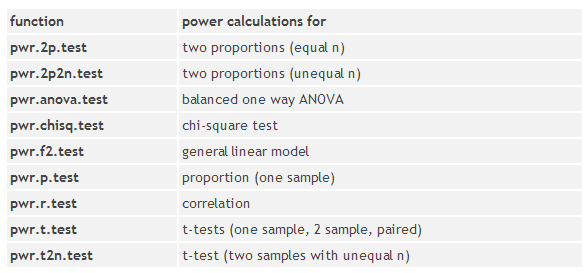

## Let's try a correlation power analysis:

### minimum detectable correlation with n = 50

```
# install pwr
install.packages("pwr")
```

```r
# load pwr
library("pwr")

# specify arguments to pwr.r.test function
pwr.r.test(n = 50, r = NULL, power = 0.8)
```

```
##
##      approximate correlation power calculation (arctangh transformation)
##
##               n = 50
##               r = 0.3867
##       sig.level = 0.05
##           power = 0.8
##     alternative = two.sided
```

#### Minimum required sample size to detect r = -0.5

```r
pwr.r.test(n = NULL, r = -0.5, power = 0.8, alternative = "less")
```

```
##
##      approximate correlation power calculation (arctangh transformation)
##
##               n = 23.2
##               r = -0.5
##       sig.level = 0.05
##           power = 0.8
##     alternative = less
```

# Plotting power analysis results

### Power plot for chi-square test

- effect size = 0.1 (small effect)
- df = 2
- sample size = 5, 10, 15, … 2000

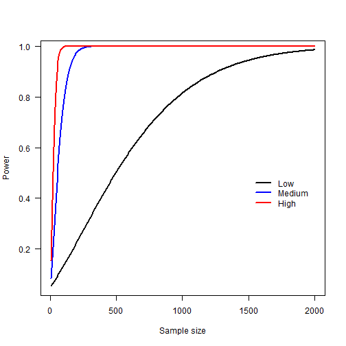

```r
# define a n
n <- seq(5, 2000, 5)

# run pwr.chisq.test for all n values where w = 0.1
chi_power_small <- sapply(n, function(x) {
    return(pwr.chisq.test(w = 0.1, N = x, df = 2)$power)
})

# run pwr.chisq.test for all n values where w = 0.3
chi_power_med <- sapply(n, function(x) {
    return(pwr.chisq.test(w = 0.3, N = x, df = 2)$power)
})

# run pwr.chisq.test for all n values where w = 0.3
chi_power_high <- sapply(n, function(x) {
    return(pwr.chisq.test(w = 0.5, N = x, df = 2)$power)
})

plot(chi_power_small ~ n, xlab = "Sample size", ylab = "Power", type = "l",
    lwd = 2, las = 1)
lines(n, chi_power_med, lwd = 2, col = "blue")
lines(n, chi_power_high, lwd = 2, col = "red")

legend(x = 1500, y = 0.5, legend = c("Low", "Medium", "High"), col = c("black",
    "blue", "red"), lwd = c(2, 2, 2), bty = "n")
```

# DIY power analysis in R (The hard way)

- Power analysis functions may not be available for some statistical  
  tests
- In these cases it is important to understand the principals of your  
  analyses so you can write your own!

### Let's do some coding!

```r
####################### # DIY power analysis # #

# T-test example

# To understand the principals of power analysis, let's look at a DIY
# t-test example.

# define a range of sample sizes
n <- seq(2, 100, 2)

# simulate two groups with a difference in means of 5%, and equal sd of 3

group1 <- rnorm(n = 1000, mean = 40, sd = 3)

group2 <- rnorm(n = 1000, mean = 42, sd = 3)

# for each element of n carry out a bunch of t-test for two samples of n
# size

# number of replicates
nsim <- 1000

# define a function to resample groups
rsGroups <- function(g1, g2, n) {
    new_g1 <- sample(g1, n, replace = TRUE)
    new_g2 <- sample(g2, n, replace = TRUE)
    list(new_g1 = new_g1, new_g2 = new_g2)
}

# example of using the function
rsGroups(group1, group2, 5)
```

```
## $new_g1
## [1] 45.35 35.80 41.29 41.83 38.50
##
## $new_g2
## [1] 41.12 40.14 41.43 41.69 40.10
```

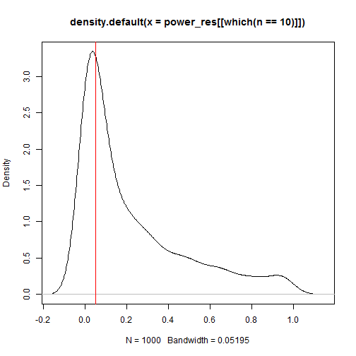

```r
power_res <- lapply(n, function(x) {
    p_vals <- sapply(1:nsim, function(...) {
        samps <- rsGroups(group1, group2, x)
        t.test(samps$new_g1, samps$new_g2)$p.value
    })
    return(p_vals)
})


# let's look at a density plot for n = 10
plot(density(power_res[[which(n == 10)]]))

# add alpha line
abline(v = 0.05, col = "red")
```

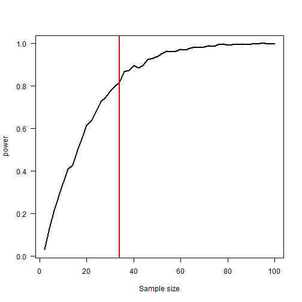

```r
# Power is the proportion of simulations to the left of the red line

# let's find out

pwrs <- sapply(power_res, function(x) {
    return(length(x[x < 0.05])/nsim)
})

# let's plot pwrs against n
plot(pwrs ~ n, type = "l", las = 1, lwd = 2, xlab = "Sample size", ylab = "power")

# what is the minimum sample size required for 80% power?
abline(v = min(n[which(pwrs >= 0.8)]), col = "red", lwd = 2)
```

```r
min(n[which(pwrs >= 0.8)])
```

```
## [1] 34
```

- Using these principals you can do power analysis for any  
  test of interest.
- **The difficult part is data simulation!!!**

# References

- Crawley, M. J. (2012). *The R book*. Wiley.
- Cohen, J. (1988). Statistical power analysis for the behavioral  
  sciences. Routledge Academic.
- Gerrodette, T. (1987). *A power analysis for detecting trends*.  
  Ecology, 1364-1372.
- Jones, O., Maillardet, R., & Robinson, A. (2009). Introduction  
  to scientific programming and simulation using R. Chapman & Hall.